# Data Visualization with Modern Data Science

> Getting Started with SQL

Kuo, Yao-Jen

## TL; DR

> In this lecture, we will set up a MySQL client for connecting to an MySQL database on AWS and a SQLite client for connecting to database locally. After setting up, we will begin data exploration with `SELECT`.

## Getting MySQL Workbench and DB Browser for SQLite(DB4S)

## Getting MySQL Workbench

- Download [MySQL Workbench](https://downloads.mysql.com/archives/workbench/) archived version
- Some Windows distributions might need to install the following prerequisites of MySQL Workbench:
  - [Microsoft .NET Framework 4.5](https://www.microsoft.com/en-us/download/details.aspx?id=30653)
  - [Visual C++ Redistributable for Visual Studio 2019](https://visualstudio.microsoft.com/en/downloads/?q=Visual+C%2B%2B+Redistributable+for+Visual+Studio+2019)

## What is MySQL Workbench, anyway?

> MySQL Workbench is a unified visual tool for database architects, developers, and DBAs.

Source: https://www.mysql.com/products/workbench/

## Why MySQL Workbench?

MySQL Workbench provides an interactive interface for SQL newbies to run queries and it fully supports MySQL Database Management System.

## Why MySQL?

You've probably heard of **LOTS** of **blah-blah SQL** before coming to this class, right?

## For instance,

- SQL Server by Microsoft
- MySQL by Oracle
- DB2 by IBM
- PostgreSQL
- SQLite
- MongoDB
- ...etc.

## We've explored [2019 Kaggle ML & DS Survey](https://www.kaggle.com/c/kaggle-survey-2019) before and there is a Question 34:

Which of the following relational database products do you use on a regular basis?

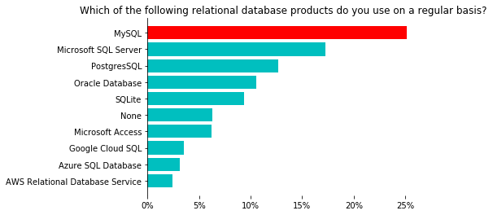

```python
plot_ans_34(ans_34_ser)
```

## Install MySQL Workbench simply by clicking

[figure not shown]

## Install MySQL Workbench simply by clicking

[figure not shown]

## Install MySQL Workbench simply by clicking

[figure not shown]

## Install MySQL Workbench simply by clicking

[figure not shown]

## Install MySQL Workbench simply by clicking

[figure not shown]

## After installation, create a new connection

- Hostname: ntu-viz-and-modern-ds.ced04jhfjfgi.ap-northeast-1.rds.amazonaws.com
- Username: ntustudent

## Your connection profile should look like this

[figure not shown]

## Click to connect

Password: 140112

[figure not shown]

## Yeah, I know the password is lame...

[figure not shown]

Source: https://giphy.com/

## We are all set with MySQL Workbench!

[figure not shown]

## Now we have a MySQL database client that is able to connect to an established database on AWS!

## Getting DB Browser for SQLite(DB4S)

Download [DB Browser for SQLite(DB4S)](https://sqlitebrowser.org/dl/)

## What is DB Browser for SQLite(DB4S), anyway?

> DB Browser for SQLite (DB4S) is a high quality, visual, open source tool to create, design, and edit database files compatible with SQLite.

Source: https://sqlitebrowser.org

## Why DB Browser for SQLite(DB4S)?

DB Browser for SQLite(DB4S) provides a familiar spreadsheet-like interface, and complicated SQL commands do not have to be learned.

## Why SQLite?

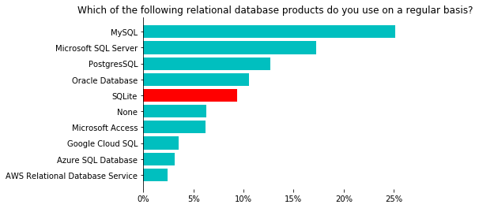

```python
plot_ans_34(ans_34_ser)
```

## Why SQLite, not so data-driven...

- It is open-sourced
- It is self-contained
- It is small and light
- And I **personally** think it is the best way for newbies to learn SQL on local machine

## Install DB Browser for SQLite(DB4S) simply by clicking

[figure not shown]

## Install DB Browser for SQLite(DB4S) simply by clicking

[figure not shown]

## Install DB Browser for SQLite(DB4S) simply by clicking

[figure not shown]

## Install DB Browser for SQLite(DB4S) simply by clicking

[figure not shown]

## Install DB Browser for SQLite(DB4S) simply by clicking

[figure not shown]

## Install DB Browser for SQLite(DB4S) simply by clicking

[figure not shown]

## Download our nba.db to connect

Open Database > Choose nba.db

## We are all set with SQLite(DB4S)!

[figure not shown]

## Now we have a SQLite database client that is able to connect to an established database in our own local machine!

## The What and Why Part for SQL

## What is SQL?

> SQL(pronounced ess-que-ell or sequel) is a language specifically designed with databases in mind. SQL enables people to create databases, add new data to them, maintain the data in them, and retrieve selected parts of the data. Developed in the 1970s at IBM, SQL has grown and advanced over the years to become the industry standard.

Source: https://www.amazon.com/SQL-Dummies-Computer-Tech/dp/1119527074/

## What is a Database?

> A database is like a collection of data items (comic books, product orders and player profile).If we define the term more strictly, a database is a **self-describing** collection of **integrated records**. A record is a representation of some physical or conceptual object.

Source: https://www.amazon.com/SQL-Dummies-Computer-Tech/dp/1119527074/

## A record as a team with 12 attributes

Send the following queries to `nba.teams` in MySQL Workbench

```
SELECT *
    FROM nba.teams
    LIMIT 5;
```

```python
pd.read_sql(sql_query, conn)
```

|  | isNBAFranchise | isAllStar | city | altCityName | fullName | tricode | teamId | nickname | urlName | teamShortName | confName | divName |
| --- | --- | --- | --- | --- | --- | --- | --- | --- | --- | --- | --- | --- |
| 0 | True | False | Atlanta | Atlanta | Atlanta Hawks | ATL | 1610612737 | Hawks | hawks | Atlanta | East | Southeast |
| 1 | True | False | Boston | Boston | Boston Celtics | BOS | 1610612738 | Celtics | celtics | Boston | East | Atlantic |
| 2 | True | False | Brooklyn | Brooklyn | Brooklyn Nets | BKN | 1610612751 | Nets | nets | Brooklyn | East | Atlantic |
| 3 | True | False | Charlotte | Charlotte | Charlotte Hornets | CHA | 1610612766 | Hornets | hornets | Charlotte | East | Southeast |
| 4 | True | False | Chicago | Chicago | Chicago Bulls | CHI | 1610612741 | Bulls | bulls | Chicago | East | Central |

## A record as a player with multiple attributes

Send the following queries to `nba.players` in MySQL Workbench

```
SELECT *
    FROM nba.players
    LIMIT 5;
```

```python
pd.read_sql(sql_query, conn)
```

|  | firstName | lastName | temporaryDisplayName | personId | teamId | jersey | pos | heightFeet | heightInches | heightMeters | weightPounds | weightKilograms | dateOfBirthUTC | nbaDebutYear | yearsPro | collegeName | lastAffiliation | country |
| --- | --- | --- | --- | --- | --- | --- | --- | --- | --- | --- | --- | --- | --- | --- | --- | --- | --- | --- |
| 0 | Steven | Adams | Adams, Steven | 203500 | 1610612760 | 12 | C | 6 | 11 | 2.11 | 265 | 120.2 | 1993-07-20 | 2013 | 6 | Pittsburgh | Pittsburgh/New Zealand | New Zealand |
| 1 | Bam | Adebayo | Adebayo, Bam | 1628389 | 1610612748 | 13 | C-F | 6 | 9 | 2.06 | 255 | 115.7 | 1997-07-18 | 2017 | 2 | Kentucky | Kentucky/USA | USA |
| 2 | LaMarcus | Aldridge | Aldridge, LaMarcus | 200746 | 1610612759 | 12 | C-F | 6 | 11 | 2.11 | 250 | 113.4 | 1985-07-19 | 2006 | 13 | Texas | Texas/USA | USA |
| 3 | Kyle | Alexander | Alexander, Kyle | 1629734 | 1610612748 | 17 | F-C | 6 | 10 | 2.08 | 216 | 98.0 | 1996-10-21 | None | 0 | Tennessee | Tennessee/Canada | Canada |
| 4 | Nickeil | Alexander-Walker | Alexander-Walker, Nickeil | 1629638 | 1610612740 | 0 | G | 6 | 5 | 1.96 | 205 | 93.0 | 1998-09-02 | 2019 | 0 | Virginia Tech | Virginia Tech/Canada | Canada |

## A database consists of both data and metadata

- Metadata is the data that describes the data’s structure within a database, because the database contains a description of its own structure, it’s **self-describing**
- The records are **integrated** because it includes not only data items but also the relationships among data items

## Seriously, what the `****` is metadata?

[figure not shown]

Source: https://giphy.com/

## A glimpse of what metadata really is: `INFORMATION_SCHEMA`

We can think of `INFORMATION_SCHEMA` as a virtual database in which the tables are views for different kinds of database metadata.

```
SHOW TABLES IN INFORMATION_SCHEMA;
```

```python
pd.read_sql(sql_query, conn)
```

|  | Tables_in_information_schema |
| --- | --- |
| 0 | CHARACTER_SETS |
| 1 | COLLATIONS |
| 2 | COLLATION_CHARACTER_SET_APPLICABILITY |
| 3 | COLUMNS |
| 4 | COLUMN_PRIVILEGES |
| ... | ... |
| 58 | INNODB_SYS_COLUMNS |
| 59 | INNODB_SYS_FOREIGN |
| 60 | INNODB_SYS_TABLESTATS |
| 61 | RDS_PROCESSLIST |
| 62 | INNODB_FT_BEING_DELETED |

63 rows × 1 columns

## Metadata describes the data’s structure within a database

Take `TABLES` for instance.

```
SELECT *
    FROM INFORMATION_SCHEMA.TABLES
    WHERE TABLE_SCHEMA = 'nba';
```

```python
pd.read_sql(sql_query, conn)
```

|  | TABLE_CATALOG | TABLE_SCHEMA | TABLE_NAME | TABLE_TYPE | ENGINE | VERSION | ROW_FORMAT | TABLE_ROWS | AVG_ROW_LENGTH | DATA_LENGTH | ... | INDEX_LENGTH | DATA_FREE | AUTO_INCREMENT | CREATE_TIME | UPDATE_TIME | CHECK_TIME | TABLE_COLLATION | CHECKSUM | CREATE_OPTIONS | TABLE_COMMENT |
| --- | --- | --- | --- | --- | --- | --- | --- | --- | --- | --- | --- | --- | --- | --- | --- | --- | --- | --- | --- | --- | --- |
| 0 | def | nba | careerSummaries | BASE TABLE | InnoDB | 10 | Dynamic | 497 | 362 | 180224 | ... | 0 | 0 | None | 2020-04-09 08:06:24 | 2020-04-09 08:28:42 | None | utf8_general_ci | None |  |  |
| 1 | def | nba | players | BASE TABLE | InnoDB | 10 | Dynamic | 497 | 230 | 114688 | ... | 0 | 0 | None | 2020-04-09 05:15:30 | 2020-04-09 05:28:47 | None | utf8_general_ci | None |  |  |
| 2 | def | nba | rosters | BASE TABLE | InnoDB | 10 | Dynamic | 497 | 32 | 16384 | ... | 0 | 0 | None | 2020-04-09 05:09:58 | 2020-04-09 05:12:04 | None | utf8_general_ci | None |  |  |
| 3 | def | nba | teams | BASE TABLE | InnoDB | 10 | Dynamic | 30 | 546 | 16384 | ... | 0 | 0 | None | 2020-04-09 05:07:29 | 2020-04-09 05:08:01 | None | utf8_general_ci | None |  |  |

4 rows × 21 columns

## What is a Database Management System?

> A database management system (DBMS) is a set of programs used to define, administer, and process databases and their associated applications.

Source: https://www.amazon.com/SQL-Dummies-Computer-Tech/dp/1119527074/

## What is a Database Management System, the less technical version

> A database management system (DBMS) bridges the application program(could be a web application, programming environment, or just a client interface) and database.

## Why SQL?

SQL is not usually the first tool we choose when learning to analyze data, MS Excel/Access makes it an optional.

## We've explored 2 questions in [2019 Kaggle ML & DS Survey](https://www.kaggle.com/c/kaggle-survey-2019) in our first class:

- Q18: What programming languages do you use on a regular basis?
- Q19: What programming language would you recommend an aspiring data scientist to learn first?

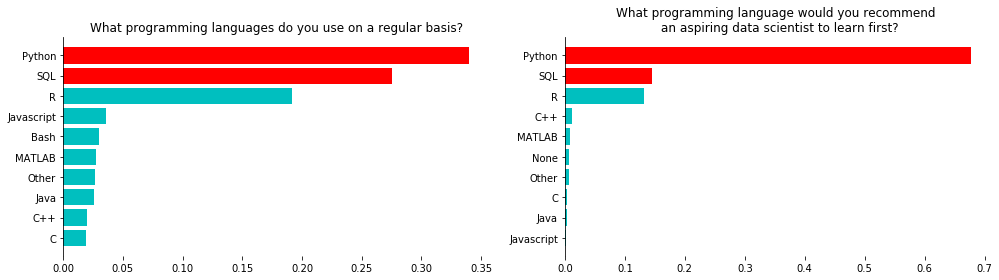

```python
plot_ans_18_19(ans_18, ans_19)
```

## Why SQL in exact

- SQL gives us improved programmatic control over the structure of data, leading to efficiency, speed, and accuracy
- SQL is also an excellent adjunct to programming languages used in the data sciences, such as R and Python
- For people with no background in programming languages, SQL often serves as an easy-to-understand introduction into concepts related to data structures and programming logic

## Why Database?

We asked ourselves, do we use database in our own laptop? No, flat files work just fine.

## Why Database in exact

- A robust database allows us to work with terabytes of data, multiple related tables, and thousands of columns
- Databases provide the backend power for many common web frameworks, interactive maps, and content management systems
- Database gives us the ability to **scale** and **automate** the standard data operations including: create, read, update, and delete

## Beginning with `SELECT`

## Basic `SELECT` syntax

A SELECT statement that fetches every row and column in a table called `nba.teams`.

```
SELECT * FROM nba.teams;
```

```python
pd.read_sql(sql_query, conn)
```

|  | isNBAFranchise | isAllStar | city | altCityName | fullName | tricode | teamId | nickname | urlName | teamShortName | confName | divName |
| --- | --- | --- | --- | --- | --- | --- | --- | --- | --- | --- | --- | --- |
| 0 | True | False | Atlanta | Atlanta | Atlanta Hawks | ATL | 1610612737 | Hawks | hawks | Atlanta | East | Southeast |
| 1 | True | False | Boston | Boston | Boston Celtics | BOS | 1610612738 | Celtics | celtics | Boston | East | Atlantic |
| 2 | True | False | Brooklyn | Brooklyn | Brooklyn Nets | BKN | 1610612751 | Nets | nets | Brooklyn | East | Atlantic |
| 3 | True | False | Charlotte | Charlotte | Charlotte Hornets | CHA | 1610612766 | Hornets | hornets | Charlotte | East | Southeast |
| 4 | True | False | Chicago | Chicago | Chicago Bulls | CHI | 1610612741 | Bulls | bulls | Chicago | East | Central |
| 5 | True | False | Cleveland | Cleveland | Cleveland Cavaliers | CLE | 1610612739 | Cavaliers | cavaliers | Cleveland | East | Central |
| 6 | True | False | Dallas | Dallas | Dallas Mavericks | DAL | 1610612742 | Mavericks | mavericks | Dallas | West | Southwest |
| 7 | True | False | Denver | Denver | Denver Nuggets | DEN | 1610612743 | Nuggets | nuggets | Denver | West | Northwest |
| 8 | True | False | Detroit | Detroit | Detroit Pistons | DET | 1610612765 | Pistons | pistons | Detroit | East | Central |
| 9 | True | False | Golden State | Golden State | Golden State Warriors | GSW | 1610612744 | Warriors | warriors | Golden State | West | Pacific |
| 10 | True | False | Houston | Houston | Houston Rockets | HOU | 1610612745 | Rockets | rockets | Houston | West | Southwest |
| 11 | True | False | Indiana | Indiana | Indiana Pacers | IND | 1610612754 | Pacers | pacers | Indiana | East | Central |
| 12 | True | False | LA | LA Clippers | LA Clippers | LAC | 1610612746 | Clippers | clippers | LA Clippers | West | Pacific |
| 13 | True | False | Los Angeles | Los Angeles Lakers | Los Angeles Lakers | LAL | 1610612747 | Lakers | lakers | L.A. Lakers | West | Pacific |
| 14 | True | False | Memphis | Memphis | Memphis Grizzlies | MEM | 1610612763 | Grizzlies | grizzlies | Memphis | West | Southwest |
| 15 | True | False | Miami | Miami | Miami Heat | MIA | 1610612748 | Heat | heat | Miami | East | Southeast |
| 16 | True | False | Milwaukee | Milwaukee | Milwaukee Bucks | MIL | 1610612749 | Bucks | bucks | Milwaukee | East | Central |
| 17 | True | False | Minnesota | Minnesota | Minnesota Timberwolves | MIN | 1610612750 | Timberwolves | timberwolves | Minnesota | West | Northwest |
| 18 | True | False | New Orleans | New Orleans | New Orleans Pelicans | NOP | 1610612740 | Pelicans | pelicans | New Orleans | West | Southwest |
| 19 | True | False | New York | New York | New York Knicks | NYK | 1610612752 | Knicks | knicks | New York | East | Atlantic |
| 20 | True | False | Oklahoma City | Oklahoma City | Oklahoma City Thunder | OKC | 1610612760 | Thunder | thunder | Oklahoma City | West | Northwest |
| 21 | True | False | Orlando | Orlando | Orlando Magic | ORL | 1610612753 | Magic | magic | Orlando | East | Southeast |
| 22 | True | False | Philadelphia | Philadelphia | Philadelphia 76ers | PHI | 1610612755 | 76ers | sixers | Philadelphia | East | Atlantic |
| 23 | True | False | Phoenix | Phoenix | Phoenix Suns | PHX | 1610612756 | Suns | suns | Phoenix | West | Pacific |
| 24 | True | False | Portland | Portland | Portland Trail Blazers | POR | 1610612757 | Trail Blazers | blazers | Portland | West | Northwest |
| 25 | True | False | Sacramento | Sacramento | Sacramento Kings | SAC | 1610612758 | Kings | kings | Sacramento | West | Pacific |
| 26 | True | False | San Antonio | San Antonio | San Antonio Spurs | SAS | 1610612759 | Spurs | spurs | San Antonio | West | Southwest |
| 27 | True | False | Toronto | Toronto | Toronto Raptors | TOR | 1610612761 | Raptors | raptors | Toronto | East | Atlantic |
| 28 | True | False | Utah | Utah | Utah Jazz | UTA | 1610612762 | Jazz | jazz | Utah | West | Northwest |
| 29 | True | False | Washington | Washington | Washington Wizards | WAS | 1610612764 | Wizards | wizards | Washington | East | Southeast |

## The above single line of code shows the most basic form of a SQL query

- The asterisk following the `SELECT` keyword is a wildcard. Here, it’s shorthand for "select all columns"
- The `FROM` keyword indicates we want the query to return data from a particular table. The semicolon after the table name tells MySQL it’s the end of the query statement

## Let's move on querying a subset of columns

It’s more practical to limit the columns the query retrieves, especially with large tables

```
SELECT firstName, lastName, dateOfBirthUTC FROM nba.players;
```

```python
pd.read_sql(sql_query, conn)
```

|  | firstName | lastName | dateOfBirthUTC |
| --- | --- | --- | --- |
| 0 | Steven | Adams | 1993-07-20 |
| 1 | Bam | Adebayo | 1997-07-18 |
| 2 | LaMarcus | Aldridge | 1985-07-19 |
| 3 | Kyle | Alexander | 1996-10-21 |
| 4 | Nickeil | Alexander-Walker | 1998-09-02 |
| ... | ... | ... | ... |
| 492 | Thaddeus | Young | 1988-06-21 |
| 493 | Trae | Young | 1998-09-19 |
| 494 | Cody | Zeller | 1992-10-05 |
| 495 | Ante | Zizic | 1997-01-04 |
| 496 | Ivica | Zubac | 1997-03-18 |

497 rows × 3 columns

## Using `DISTINCT` to find unique values

- It is common for a column to contain rows with duplicates
- To understand the range of values in a column, we can use the `DISTINCT` keyword

```
SELECT DISTINCT confName, divName FROM nba.teams;
```

```python
pd.read_sql(sql_query, conn)
```

|  | confName | divName |
| --- | --- | --- |
| 0 | East | Southeast |
| 1 | East | Atlantic |
| 2 | East | Central |
| 3 | West | Southwest |
| 4 | West | Northwest |
| 5 | West | Pacific |

## Sorting data with `ORDER BY`

We order the results of a query using the keywords `ORDER BY` followed by the name of the column(s) to sort.

```
SELECT personId, points
    FROM nba.careerSummaries
    ORDER BY points;
```

```python
pd.read_sql(sql_query, conn)
```

|  | personId | points |
| --- | --- | --- |
| 0 | 1629734 | NaN |
| 1 | 1629626 | NaN |
| 2 | 1629719 | NaN |
| 3 | 1626218 | NaN |
| 4 | 1629007 | NaN |
| ... | ... | ... |
| 492 | 201935 | 20723.0 |
| 493 | 201142 | 22940.0 |
| 494 | 1713 | 25728.0 |
| 495 | 2546 | 26314.0 |
| 496 | 2544 | 34087.0 |

497 rows × 2 columns

## By default, `ORDER BY` sorts values in ascending order

If we want to sort in descending order, add the `DESC` keyword.

```
SELECT personId, points
    FROM nba.careerSummaries
    ORDER BY points DESC;
```

```python
pd.read_sql(sql_query, conn)
```

|  | personId | points |
| --- | --- | --- |
| 0 | 2544 | 34087.0 |
| 1 | 2546 | 26314.0 |
| 2 | 1713 | 25728.0 |
| 3 | 201142 | 22940.0 |
| 4 | 201935 | 20723.0 |
| ... | ... | ... |
| 492 | 1629719 | NaN |
| 493 | 1626218 | NaN |
| 494 | 1629007 | NaN |
| 495 | 1629685 | NaN |
| 496 | 1629624 | NaN |

497 rows × 2 columns

## We are not limited to sorting on just one column

```
SELECT firstName, lastName, dateOfBirthUTC
    FROM nba.players
    ORDER BY firstName, dateOfBirthUTC DESC;
```

```python
pd.read_sql(sql_query, conn)
```

|  | firstName | lastName | dateOfBirthUTC |
| --- | --- | --- | --- |
| 0 | Aaron | Holiday | 1996-09-30 |
| 1 | Aaron | Gordon | 1995-09-16 |
| 2 | Abdel | Nader | 1993-09-25 |
| 3 | Adam | Mokoka | 1998-07-18 |
| 4 | Admiral | Schofield | 1997-03-30 |
| ... | ... | ... | ... |
| 492 | Zach | Collins | 1997-11-19 |
| 493 | Zach | LaVine | 1995-03-10 |
| 494 | Zhaire | Smith | 1999-06-04 |
| 495 | Zion | Williamson | 2000-07-06 |
| 496 | Zylan | Cheatham | 1995-11-17 |

497 rows × 3 columns

## Filtering rows with `WHERE`

The `WHERE` keyword allows us to find rows that match a specific value, a range of values, or multiple values.

```
SELECT personId, firstName, lastName
    FROM nba.players
    WHERE lastName = 'James';
```

```python
pd.read_sql(sql_query, conn)
```

|  | personId | firstName | lastName |
| --- | --- | --- | --- |
| 0 | 1629713 | Justin | James |
| 1 | 2544 | LeBron | James |

## The above query uses equals comparison operator `=` to find rows that exactly match, but we can use other operators

## Comparison and matching operators

- `=`: Equal to
- `!=`: Not equal to
- `>`, `>=`: Greater than; Greater than or equal to
- `<`, `<=`: Less than; Less than or equal to
- `BETWEEN`: Within a range
- `IN`: Match one of a set of values
- `LIKE`: Match a pattern
- `NOT`: Negates a condition

## Using the `BETWEEN` operator

```
SELECT personId, ppg
    FROM nba.careerSummaries
    WHERE ppg BETWEEN 20 AND 25;
```

```python
pd.read_sql(sql_query, conn)
```

|  | personId | ppg |
| --- | --- | --- |
| 0 | 203507 | 20.0 |
| 1 | 2546 | 23.6 |
| 2 | 203078 | 21.0 |
| 3 | 1626164 | 22.3 |
| 4 | 201939 | 23.5 |
| 5 | 203076 | 24.0 |
| 6 | 201942 | 20.0 |
| 7 | 1629029 | 24.4 |
| 8 | 203954 | 24.1 |
| 9 | 201933 | 21.7 |
| 10 | 202681 | 22.4 |
| 11 | 203081 | 24.0 |
| 12 | 1628378 | 22.7 |
| 13 | 1626157 | 22.7 |
| 14 | 202689 | 20.0 |
| 15 | 201566 | 23.2 |
| 16 | 1629627 | 23.6 |
| 17 | 1629027 | 23.6 |

## Using `LIKE` with `WHERE`

Comparison operators are fairly straightforward, but `LIKE` deserves additional explanation.

## `LIKE` lets us search for patterns in strings by using two special characters

- Percent sign `%`: A wildcard matching one or more characters
- Underscore `_`: A wildcard matching just one character

## Using `LIKE` with `WHERE` and `%`

```
SELECT firstName, lastName
    FROM nba.players
    WHERE firstName LIKE 'K%';
```

```python
pd.read_sql(sql_query, conn)
```

|  | firstName | lastName |
| --- | --- | --- |
| 0 | Kyle | Alexander |
| 1 | Kadeem | Allen |
| 2 | Kyle | Anderson |
| 3 | Kostas | Antetokounmpo |
| 4 | Keita | Bates-Diop |
| 5 | Kent | Bazemore |
| 6 | Khem | Birch |
| 7 | Ky | Bowman |
| 8 | Kentavious | Caldwell-Pope |
| 9 | Kris | Dunn |
| 10 | Kevin | Durant |
| 11 | Kyle | Guy |
| 12 | Kevin | Hervey |
| 13 | Kevin | Huerter |
| 14 | Kyrie | Irving |
| 15 | Keldon | Johnson |
| 16 | Kevin | Knox II |
| 17 | Kyle | Korver |
| 18 | Kyle | Kuzma |
| 19 | Kawhi | Leonard |
| 20 | Kevon | Looney |
| 21 | Kevin | Love |
| 22 | Kyle | Lowry |
| 23 | Kelan | Martin |
| 24 | Khris | Middleton |
| 25 | Kendrick | Nunn |
| 26 | Kyle | O'Quinn |
| 27 | KZ | Okpala |
| 28 | Kelly | Olynyk |
| 29 | Kelly | Oubre Jr. |
| 30 | Kevin | Porter Jr. |
| 31 | Kristaps | Porzingis |
| 32 | Kobi | Simmons |
| 33 | Khyri | Thomas |
| 34 | Klay | Thompson |
| 35 | Karl-Anthony | Towns |
| 36 | Kemba | Walker |
| 37 | Kenrich | Williams |
| 38 | Kenny | Wooten |

## Using `LIKE` with `WHERE` and `_`

```
SELECT firstName, lastName
    FROM nba.players
    WHERE firstName LIKE 'K____'; -- 4 underlines
```

```python
pd.read_sql(sql_query, conn)
```

|  | firstName | lastName |
| --- | --- | --- |
| 0 | Keita | Bates-Diop |
| 1 | Kevin | Durant |
| 2 | Kevin | Hervey |
| 3 | Kevin | Huerter |
| 4 | Kyrie | Irving |
| 5 | Kevin | Knox II |
| 6 | Kawhi | Leonard |
| 7 | Kevon | Looney |
| 8 | Kevin | Love |
| 9 | Kelan | Martin |
| 10 | Khris | Middleton |
| 11 | Kelly | Olynyk |
| 12 | Kelly | Oubre Jr. |
| 13 | Kevin | Porter Jr. |
| 14 | Khyri | Thomas |
| 15 | Kemba | Walker |
| 16 | Kenny | Wooten |

## Combining conditions with `AND` and `OR`

Comparison operators become more useful when we combine them. To do this, we connect them using keywords `AND` and `OR`.

## Combining conditions with `AND`

```
SELECT firstName, lastName
    FROM nba.players
    WHERE firstName LIKE 'K%'
          AND lastName LIKE 'L%';
```

```python
pd.read_sql(sql_query, conn)
```

|  | firstName | lastName |
| --- | --- | --- |
| 0 | Kawhi | Leonard |
| 1 | Kevon | Looney |
| 2 | Kevin | Love |
| 3 | Kyle | Lowry |

## Combining conditions with `OR`

```
SELECT firstName, lastName
    FROM nba.players
    WHERE firstName LIKE 'K%'
          OR lastName LIKE 'L%';
```

```python
pd.read_sql(sql_query, conn)
```

|  | firstName | lastName |
| --- | --- | --- |
| 0 | Kyle | Alexander |
| 1 | Kadeem | Allen |
| 2 | Kyle | Anderson |
| 3 | Kostas | Antetokounmpo |
| 4 | Keita | Bates-Diop |
| 5 | Kent | Bazemore |
| 6 | Khem | Birch |
| 7 | Ky | Bowman |
| 8 | Kentavious | Caldwell-Pope |
| 9 | Kris | Dunn |
| 10 | Kevin | Durant |
| 11 | Kyle | Guy |
| 12 | Kevin | Hervey |
| 13 | Kevin | Huerter |
| 14 | Kyrie | Irving |
| 15 | Keldon | Johnson |
| 16 | Kevin | Knox II |
| 17 | Kyle | Korver |
| 18 | Kyle | Kuzma |
| 19 | Skal | Labissiere |
| 20 | Jeremy | Lamb |
| 21 | Romeo | Langford |
| 22 | Zach | LaVine |
| 23 | Vic | Law |
| 24 | Jake | Layman |
| 25 | TJ | Leaf |
| 26 | Jalen | Lecque |
| 27 | Courtney | Lee |
| 28 | Damion | Lee |
| 29 | Alex | Len |
| 30 | Kawhi | Leonard |
| 31 | Meyers | Leonard |
| 32 | Caris | LeVert |
| 33 | Damian | Lillard |
| 34 | Nassir | Little |
| 35 | Kevon | Looney |
| 36 | Brook | Lopez |
| 37 | Robin | Lopez |
| 38 | Kevin | Love |
| 39 | Kyle | Lowry |
| 40 | Timothe | Luwawu-Cabarrot |
| 41 | Trey | Lyles |
| 42 | Kelan | Martin |
| 43 | Khris | Middleton |
| 44 | Kendrick | Nunn |
| 45 | Kyle | O'Quinn |
| 46 | KZ | Okpala |
| 47 | Kelly | Olynyk |
| 48 | Kelly | Oubre Jr. |
| 49 | Kevin | Porter Jr. |
| 50 | Kristaps | Porzingis |
| 51 | Kobi | Simmons |
| 52 | Khyri | Thomas |
| 53 | Klay | Thompson |
| 54 | Karl-Anthony | Towns |
| 55 | Kemba | Walker |
| 56 | Kenrich | Williams |
| 57 | Kenny | Wooten |

## Putting what we have so far all together

SQL is about the order of keywords, so follow this convention:

```
SELECT column_names
    FROM table_name
    WHERE conditions
    ORDER BY column_names;
```

## You may still feel confused about several things

- How to comment our queries?
- Is it case-sensitive or not?
- When to indent or when not to?
- What is the naming rule, say snake case or camel case?
- ...etc.

## Don't worry, we will start with style guide in our next lecture!

[figure not shown]

Source: https://giphy.com/

## That's all for today, stay healthy and safe :)